# AZT 처치 시점과 AIDS 증상 범주의 상대적 구조

# 1 분석 질문

AZT를 즉시 투여한 집단과 면역 지표가 더 악화될 때까지 투여를 미룬 집단에서 AIDS 증상 여부의 상대적 연관 구조는 어떻게 나타나는가?

# 2 분할표

자료는 338명의 3년 추적 결과를 집계한 2×2 표다. 자료 정의는 Agresti(2002)에 수록되었고 R의 `brglm2::aids` 문서에도 공개되어 있다.

```r
O <- matrix(
  c(25, 145,
    44, 124),
  nrow = 2, byrow = TRUE,
  dimnames = list(
    AZT = c("Immediate", "Deferred"),
    Symptoms = c("Yes", "No")
  )
)
knitr::kable(O, caption = "AZT 처치 시점 × AIDS 증상 집계표")
```

AZT 처치 시점 × AIDS 증상 집계표

|  | Yes | No |
| --- | --- | --- |
| Immediate | 25 | 145 |
| Deferred | 44 | 124 |

```r
row_percent <- 100 * prop.table(O, margin = 1)
knitr::kable(row_percent, digits = 1,
             caption = "처치 집단별 증상 비율(%)")
```

처치 집단별 증상 비율(%)

|  | Yes | No |
| --- | --- | --- |
| Immediate | 14.7 | 85.3 |
| Deferred | 26.2 | 73.8 |

즉시 처치군의 증상 발생 비율은 14.7%, 지연 처치군은 26.2%다.

# 3 독립성 검정

```r
chi <- chisq.test(O, correct = FALSE)
cramers_v <- sqrt(unname(chi$statistic) / sum(O))
test_result <- data.frame(
  chi_square = unname(chi$statistic),
  df = unname(chi$parameter),
  p_value = chi$p.value,
  cramers_v = cramers_v,
  min_expected = min(chi$expected)
)
knitr::kable(test_result, digits = 4,
             caption = "Pearson 카이제곱 독립성 검정")
```

Pearson 카이제곱 독립성 검정

| chi_square | df | p_value | cramers_v | min_expected |
| --- | --- | --- | --- | --- |
| 6.8597 | 1 | 0.0088 | 0.1425 | 34.2959 |

기대도수는 모두 충분히 크고, 독립성 가정에서 관찰된 차이보다 큰 차이를 얻을 p-value는 0.0088이다. 효과크기 Cramér’s V는 0.142로, 통계적으로 유의한 차이가 강한 연관성을 뜻하지는 않는다. 집계표만으로 임상적 인과효과나 일반화 가능성을 확정할 수도 없다.

# 4 대응분석

```r
P <- O / sum(O)
r <- rowSums(P)
c_mass <- colSums(P)
Dr_inv_sqrt <- diag(1 / sqrt(r))
Dc_inv_sqrt <- diag(1 / sqrt(c_mass))

standardized <- Dr_inv_sqrt %*%
  (P - outer(r, c_mass)) %*%
  Dc_inv_sqrt
decomp <- svd(standardized)

eigenvalues <- decomp$d^2
row_coord <- Dr_inv_sqrt %*% decomp$u %*% diag(decomp$d)
col_coord <- Dc_inv_sqrt %*% decomp$v %*% diag(decomp$d)
rownames(row_coord) <- rownames(O)
rownames(col_coord) <- colnames(O)

inertia <- data.frame(
  dimension = seq_along(eigenvalues),
  eigenvalue = eigenvalues,
  percent = 100 * eigenvalues / sum(eigenvalues)
)
knitr::kable(inertia, digits = 5,
             caption = "대응분석 고유값과 관성 비율")
```

대응분석 고유값과 관성 비율

| dimension | eigenvalue | percent |
| --- | --- | --- |
| 1 | 0.02029 | 100 |
| 2 | 0.00000 | 0 |

2×2 분할표에서는 두 범주의 연관 구조가 하나의 축으로 요약된다. 두 번째 축은 수치 오차 수준이므로 2차원 평면 대신 1차원에서 상대적 위치를 표시한다.

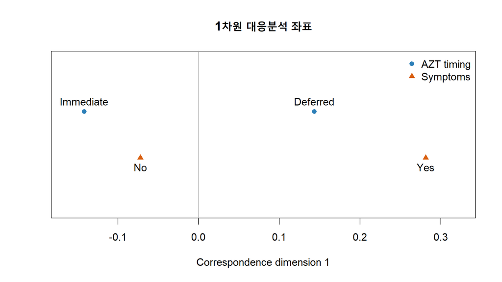

```r
row_x <- row_coord[, 1]
col_x <- col_coord[, 1]
xlim <- range(c(row_x, col_x)) * 1.15
plot(NA, xlim = xlim, ylim = c(-0.4, 0.4),
     xlab = "Correspondence dimension 1", ylab = "",
     yaxt = "n", main = "1차원 대응분석 좌표")
abline(v = 0, col = "grey70")
points(row_x, rep(0.12, length(row_x)), pch = 16, col = "#2C7FB8")
text(row_x, rep(0.12, length(row_x)), labels = names(row_x), pos = 3)
points(col_x, rep(-0.12, length(col_x)), pch = 17, col = "#D95F0E")
text(col_x, rep(-0.12, length(col_x)), labels = names(col_x), pos = 1)
legend("topright", c("AZT timing", "Symptoms"), pch = c(16, 17),
       col = c("#2C7FB8", "#D95F0E"), bty = "n")
```

즉시 처치와 무증상, 지연 처치와 증상 있음이 각각 같은 상대적 방향에 놓인다. 즉시 처치군에서 증상 발생 비율이 더 낮게 관찰됐지만, 이 그림은 독립모형에서 벗어난 상대적 구조를 요약할 뿐이다. 점 사이 거리나 방향을 임상적 효과크기 또는 인과 방향으로 읽어서는 안 된다.

# 5 한계

- 공개된 집계표만으로 표본 모집, 무작위화 실행, 추적 손실, 기저 위험을 재검증할 수 없다.
- 원본 분석의 race×AZT×symptoms Burt matrix는 표본 정의와 다중 대응분석 해석을 더 명확히 해야 하므로 주 분석에서 제외했다.
- 2×2 표는 연관 구조가 하나의 축으로만 표현되므로 CA의 차원 축소 이점이 작다. 카이제곱 검정, Cramér’s V와 조건부 비율이 더 직접적이다.
- 시각적 방향과 근접성은 범주 간 상대적 연관이며 임상적 인과관계가 아니다.